# “Nigeria Weather Analysis Dashboard”

Samson. O

2026-04-18

## Environmemt Setup

This analysis uses the following R packages:

- **dplyr** for data manipulation
- **tidyr** for data reshaping
- **ggplot2** for data visualization
- **knitr** for table formatting

```r
library(dplyr)
library(tidyr)
library(ggplot2)
library(knitr)
```

### Introduction

This report analyzes temperature and rainfall patterns across major Nigerian cities. Using R and the tidyverse ecosystem, the analysis explores trends, compares cities, and highlights key environmental insights that could inform urban planning and climate adaptation strategies.

### Data Creation

The dataset simulates 5 days of weather observations across 4 Nigerian cities: Lagos, Abuja, Port Harcourt, and Kano.

```r
weather <- data.frame(
  city = rep(c("Lagos", "Abuja", "Port Harcourt", "Kano"), each = 5),
  day = rep(1:5, times = 4),
  temperature = c(32, 34, 33, 35, 36,
                  30, 31, 32, 33, 34,
                  31, 32, 33, 34, 35,
                  35, 36, 37, 38, 39),
  rainfall = c(10, 5, 8, 2, 0,
               2, 0, 1, 0, 0,
               12, 10, 8, 6, 4,
               0, 0, 0, 0, 0)
)

kable(head(weather, 10),
      caption = "Sample of Weather Data (First 10 Rows)",
      col.names = c("City", "Day", "Temperature (°C)", "Rainfall (mm)"))
```

Sample of Weather Data (First 10 Rows)

| City | Day | Temperature (°C) | Rainfall (mm) |
| --- | --- | --- | --- |
| Lagos | 1 | 32 | 10 |
| Lagos | 2 | 34 | 5 |
| Lagos | 3 | 33 | 8 |
| Lagos | 4 | 35 | 2 |
| Lagos | 5 | 36 | 0 |
| Abuja | 1 | 30 | 2 |
| Abuja | 2 | 31 | 0 |
| Abuja | 3 | 32 | 1 |
| Abuja | 4 | 33 | 0 |
| Abuja | 5 | 34 | 0 |

### Data Cleaning

A new variable (`temp_status`) was created to classify temperature levels into three categories: Normal, Hot, and Very Hot.

```r
weather_clean <- weather %>%
  mutate(temp_status = case_when(
       temperature >= 37 ~ "Very Hot",
       temperature >= 33 ~ "Hot",
       TRUE ~ "Normal"))

kable(head(weather_clean, 10),
      caption = "Cleaned Weather Data with Temperature Status",
      col.names = c("City", "Day", "Temperature (°C)",
                    "Rainfall (mm)", "Temperature Status"))
```

Cleaned Weather Data with Temperature Status

| City | Day | Temperature (°C) | Rainfall (mm) | Temperature Status |
| --- | --- | --- | --- | --- |
| Lagos | 1 | 32 | 10 | Normal |
| Lagos | 2 | 34 | 5 | Hot |
| Lagos | 3 | 33 | 8 | Hot |
| Lagos | 4 | 35 | 2 | Hot |
| Lagos | 5 | 36 | 0 | Hot |
| Abuja | 1 | 30 | 2 | Normal |
| Abuja | 2 | 31 | 0 | Normal |
| Abuja | 3 | 32 | 1 | Normal |
| Abuja | 4 | 33 | 0 | Hot |
| Abuja | 5 | 34 | 0 | Hot |

### Data Analysis

```r
summary_table <- weather_clean %>%
  group_by(city) %>%
  summarise(
    avg_temp_per_city = mean(temperature),
    total_rainfall_per_city = sum(rainfall),
    max_temp_per_city = max(temperature), .groups = "drop") %>%
    arrange(desc(avg_temp_per_city)) %>%
    mutate(
      metric = case_when(
      total_rainfall_per_city > 20 ~
                              "High Rainfall",
                            TRUE ~ "Low Rainfall"
)
  )


kable(summary_table,
      caption = "Summary Statistics by City",
      col.names = c("City", "Avg Temperature (°C)", "Total Rainfall (mm)",
                    "Max Temperature (°C)", "Rainfall Category"),
      digits = 1)
```

Summary Statistics by City

| City | Avg Temperature (°C) | Total Rainfall (mm) | Max Temperature (°C) | Rainfall Category |
| --- | --- | --- | --- | --- |
| Kano | 37 | 0 | 39 | Low Rainfall |
| Lagos | 34 | 25 | 36 | High Rainfall |
| Port Harcourt | 33 | 40 | 35 | High Rainfall |
| Abuja | 32 | 3 | 34 | Low Rainfall |

### Visualizations

#### Average Temperature by City

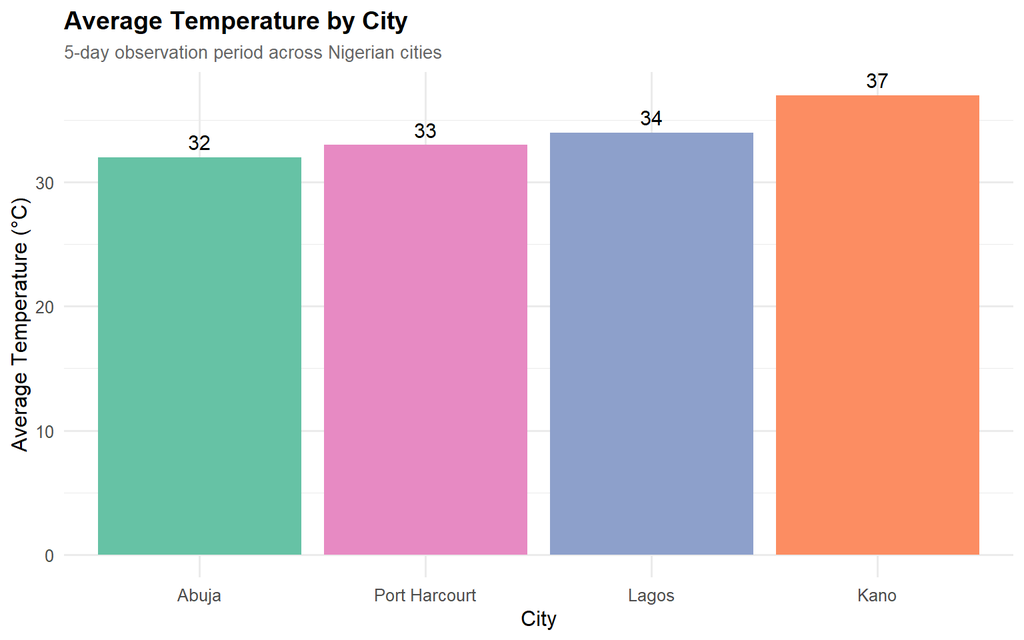

```r
ggplot(data = summary_table,
      aes(x = reorder(city, avg_temp_per_city),
          y = avg_temp_per_city,
          fill = city)) +
  geom_col(show.legend = FALSE) +
  geom_text(aes(label = round(avg_temp_per_city, 1)),
         vjust = -0.5,
         size = 4) +
 scale_fill_brewer(palette = "Set2") +
  labs(
    title = "Average Temperature by City",
    subtitle = "5-day observation period across Nigerian cities",
    x = "City",
    y = "Average Temperature (°C)"
  ) +
  theme_minimal(base_size = 12) +
  theme(
    plot.title = element_text(face = "bold", size = 14),
    plot.subtitle = element_text(size = 10, color = "gray40")
    )
```

#### Temperature Trends Over Time

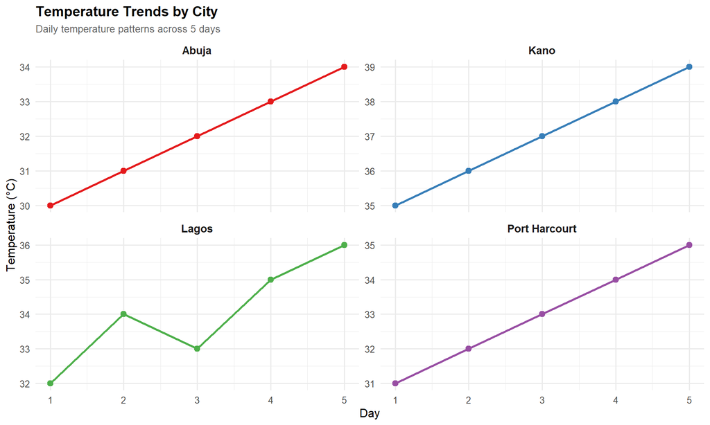

```r
ggplot(data = weather_clean,
       aes(x = day, y = temperature, color = city, group = city)) +
  geom_line(size = 1) +
  geom_point(size = 2.5) +
  scale_color_brewer(palette = "Set1") +
  labs(
    title = "Temperature Trends by City",
    subtitle = "Daily temperature patterns across 5 days",
    x = "Day",
    y = "Temperature (°C)",
    color = "City"
  ) +
  facet_wrap(~ city, scales = "free_y") +
  theme_minimal(base_size = 12) +
  theme(
    plot.title = element_text(face = "bold", size = 14),
    plot.subtitle = element_text(size = 10, color = "gray40"),
    legend.position = "none",
    strip.text = element_text(face = "bold", size = 11)
  )
```

#### Total Rainfall Distribution

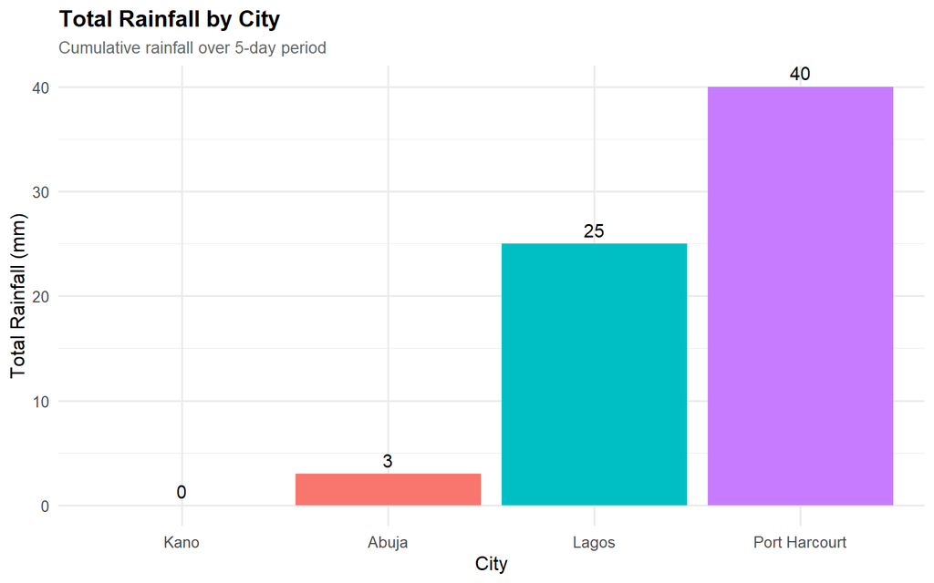

```r
ggplot(data = summary_table,
       aes(x = reorder(city, total_rainfall_per_city),
           y = total_rainfall_per_city,
           fill = city)) +
  geom_col(show.legend = FALSE) +
  geom_text(aes(label = total_rainfall_per_city),
            vjust = -0.5,
            size = 4) +
  labs(
    title = "Total Rainfall by City",
    subtitle = "Cumulative rainfall over 5-day period",
    x = "City",
    y = "Total Rainfall (mm)"
  ) +
  theme_minimal(base_size = 12) +
  theme(
    plot.title = element_text(face = "bold", size = 14),
    plot.subtitle = element_text(size = 10, color = "gray40"),
    legend.position = "top"
)
```

### Conclusion

This analysis demonstrates how R and the tidyverse ecosystem can be effectively used to explore and visualize environmental data. The findings reveal distinct climate patterns across Nigerian cities, with **Kano’s extreme heat** and **Port Harcourt’s high rainfall** suggesting different environmental conditions that may require tailored urban planning and climate adaptation strategies.

Future improvements to this analysis could include:

- Integration of real meteorological data from the Nigerian Meteorological Agency (NiMet)
- Expansion to monthly or yearly time scales for seasonal pattern analysis
- Addition of humidity, wind speed, and other climate variables
- Statistical testing to determine significance of observed differences
- Development of an interactive Shiny dashboard for real-time exploration